# Optimal Treatment Analysis

## Outcome Variable

**Outcome Variable:** whz

## Predictor Variables

**Intervention Variable:** impfloor

**Adjustment Set:**

- arm
- sex
- W_mage
- meducyrs
- feducyrs
- hhwealth_quart
- hfoodsec
- W_mhtcm
- W_nrooms
- W_nchldlt5
- W_parity
- impsan
- safeh20
- delta_W_mage
- delta_meducyrs
- delta_feducyrs
- delta_hhwealth_quart
- delta_hfoodsec
- delta_W_mhtcm
- delta_W_nrooms
- delta_W_nchldlt5
- delta_W_parity
- delta_impsan
- delta_safeh20

## Stratifying Variables

The analysis was stratified on these variable(s):

- agecat
- studyid
- country

## Data Summary

| agecat | studyid | country | impfloor | n_cell | n |
| --- | --- | --- | --- | --- | --- |
| Birth | ki0047075b-MAL-ED | BANGLADESH | 1 | 205 | 222 |
| Birth | ki0047075b-MAL-ED | BANGLADESH | 0 | 17 | 222 |
| Birth | ki0047075b-MAL-ED | BRAZIL | 1 | 165 | 167 |
| Birth | ki0047075b-MAL-ED | BRAZIL | 0 | 2 | 167 |
| Birth | ki0047075b-MAL-ED | INDIA | 1 | 178 | 188 |
| Birth | ki0047075b-MAL-ED | INDIA | 0 | 10 | 188 |
| Birth | ki0047075b-MAL-ED | NEPAL | 1 | 64 | 159 |
| Birth | ki0047075b-MAL-ED | NEPAL | 0 | 95 | 159 |
| Birth | ki0047075b-MAL-ED | PERU | 1 | 54 | 252 |
| Birth | ki0047075b-MAL-ED | PERU | 0 | 198 | 252 |
| Birth | ki0047075b-MAL-ED | SOUTH AFRICA | 1 | 196 | 216 |
| Birth | ki0047075b-MAL-ED | SOUTH AFRICA | 0 | 20 | 216 |
| Birth | ki0047075b-MAL-ED | TANZANIA, UNITED REPUBLIC OF | 1 | 7 | 113 |
| Birth | ki0047075b-MAL-ED | TANZANIA, UNITED REPUBLIC OF | 0 | 106 | 113 |
| Birth | ki1000108-CMC-V-BCS-2002 | INDIA | 1 | 71 | 71 |
| Birth | ki1000108-CMC-V-BCS-2002 | INDIA | 0 | 0 | 71 |
| Birth | ki1000108-IRC | INDIA | 1 | 253 | 253 |
| Birth | ki1000108-IRC | INDIA | 0 | 0 | 253 |
| Birth | ki1017093-NIH-Birth | BANGLADESH | 1 | 24 | 28 |
| Birth | ki1017093-NIH-Birth | BANGLADESH | 0 | 4 | 28 |
| Birth | ki1017093c-NIH-Crypto | BANGLADESH | 1 | 18 | 23 |
| Birth | ki1017093c-NIH-Crypto | BANGLADESH | 0 | 5 | 23 |
| Birth | ki1114097-CONTENT | PERU | 1 | 2 | 2 |
| Birth | ki1114097-CONTENT | PERU | 0 | 0 | 2 |
| Birth | kiGH5241-JiVitA-3 | BANGLADESH | 1 | 925 | 15666 |
| Birth | kiGH5241-JiVitA-3 | BANGLADESH | 0 | 14741 | 15666 |
| Birth | kiGH5241-JiVitA-4 | BANGLADESH | 1 | 58 | 683 |
| Birth | kiGH5241-JiVitA-4 | BANGLADESH | 0 | 625 | 683 |
| 6 months | ki0047075b-MAL-ED | BANGLADESH | 1 | 221 | 240 |
| 6 months | ki0047075b-MAL-ED | BANGLADESH | 0 | 19 | 240 |

[output cut: 62 more lines]

The following strata were considered:

- agecat: 24 months, studyid: ki0047075b-MAL-ED, country: BANGLADESH
- agecat: 24 months, studyid: ki0047075b-MAL-ED, country: BRAZIL
- agecat: 24 months, studyid: ki0047075b-MAL-ED, country: INDIA
- agecat: 24 months, studyid: ki0047075b-MAL-ED, country: NEPAL
- agecat: 24 months, studyid: ki0047075b-MAL-ED, country: PERU
- agecat: 24 months, studyid: ki0047075b-MAL-ED, country: SOUTH AFRICA
- agecat: 24 months, studyid: ki0047075b-MAL-ED, country: TANZANIA, UNITED REPUBLIC OF
- agecat: 24 months, studyid: ki1000108-CMC-V-BCS-2002, country: INDIA
- agecat: 24 months, studyid: ki1000108-IRC, country: INDIA
- agecat: 24 months, studyid: ki1017093-NIH-Birth, country: BANGLADESH
- agecat: 24 months, studyid: ki1017093b-PROVIDE, country: BANGLADESH
- agecat: 24 months, studyid: ki1017093c-NIH-Crypto, country: BANGLADESH
- agecat: 24 months, studyid: ki1113344-GMS-Nepal, country: NEPAL
- agecat: 24 months, studyid: ki1114097-CONTENT, country: PERU
- agecat: 24 months, studyid: kiGH5241-JiVitA-3, country: BANGLADESH
- agecat: 24 months, studyid: kiGH5241-JiVitA-4, country: BANGLADESH
- agecat: 6 months, studyid: ki0047075b-MAL-ED, country: BANGLADESH
- agecat: 6 months, studyid: ki0047075b-MAL-ED, country: BRAZIL
- agecat: 6 months, studyid: ki0047075b-MAL-ED, country: INDIA
- agecat: 6 months, studyid: ki0047075b-MAL-ED, country: NEPAL
- agecat: 6 months, studyid: ki0047075b-MAL-ED, country: PERU
- agecat: 6 months, studyid: ki0047075b-MAL-ED, country: SOUTH AFRICA
- agecat: 6 months, studyid: ki0047075b-MAL-ED, country: TANZANIA, UNITED REPUBLIC OF
- agecat: 6 months, studyid: ki1000108-CMC-V-BCS-2002, country: INDIA
- agecat: 6 months, studyid: ki1000108-IRC, country: INDIA
- agecat: 6 months, studyid: ki1017093-NIH-Birth, country: BANGLADESH
- agecat: 6 months, studyid: ki1017093b-PROVIDE, country: BANGLADESH
- agecat: 6 months, studyid: ki1017093c-NIH-Crypto, country: BANGLADESH
- agecat: 6 months, studyid: ki1113344-GMS-Nepal, country: NEPAL
- agecat: 6 months, studyid: ki1114097-CONTENT, country: PERU
- agecat: 6 months, studyid: kiGH5241-JiVitA-3, country: BANGLADESH
- agecat: 6 months, studyid: kiGH5241-JiVitA-4, country: BANGLADESH
- agecat: Birth, studyid: ki0047075b-MAL-ED, country: BANGLADESH
- agecat: Birth, studyid: ki0047075b-MAL-ED, country: BRAZIL
- agecat: Birth, studyid: ki0047075b-MAL-ED, country: INDIA
- agecat: Birth, studyid: ki0047075b-MAL-ED, country: NEPAL
- agecat: Birth, studyid: ki0047075b-MAL-ED, country: PERU
- agecat: Birth, studyid: ki0047075b-MAL-ED, country: SOUTH AFRICA
- agecat: Birth, studyid: ki0047075b-MAL-ED, country: TANZANIA, UNITED REPUBLIC OF
- agecat: Birth, studyid: ki1000108-CMC-V-BCS-2002, country: INDIA
- agecat: Birth, studyid: ki1000108-IRC, country: INDIA
- agecat: Birth, studyid: ki1017093-NIH-Birth, country: BANGLADESH
- agecat: Birth, studyid: ki1017093c-NIH-Crypto, country: BANGLADESH
- agecat: Birth, studyid: ki1114097-CONTENT, country: PERU
- agecat: Birth, studyid: kiGH5241-JiVitA-3, country: BANGLADESH
- agecat: Birth, studyid: kiGH5241-JiVitA-4, country: BANGLADESH

### Dropped Strata

- agecat: Birth, studyid: ki0047075b-MAL-ED, country: BRAZIL
- agecat: Birth, studyid: ki1000108-CMC-V-BCS-2002, country: INDIA
- agecat: Birth, studyid: ki1000108-IRC, country: INDIA
- agecat: Birth, studyid: ki1017093-NIH-Birth, country: BANGLADESH
- agecat: Birth, studyid: ki1114097-CONTENT, country: PERU
- agecat: 6 months, studyid: ki0047075b-MAL-ED, country: BRAZIL
- agecat: 6 months, studyid: ki1000108-CMC-V-BCS-2002, country: INDIA
- agecat: 6 months, studyid: ki1000108-IRC, country: INDIA
- agecat: 24 months, studyid: ki0047075b-MAL-ED, country: BRAZIL
- agecat: 24 months, studyid: ki1000108-CMC-V-BCS-2002, country: INDIA
- agecat: 24 months, studyid: ki1000108-IRC, country: INDIA

## Methods Detail

We’re interested in the causal parameters $E[Y_a]$ for all values of $a \in \mathcal{A}$. These parameters represent the mean outcome if, possibly contrary to fact, we intervened to set all units to have $A=a$. Under the randomization and positivity assumptions, these are identified by the statistical parameters $\psi_a=E_W[E_{Y|A,W}(Y|A=a,W)]$. In addition, we’re interested in the mean of $Y$, $E[Y]$ under no intervention (the observed mean). We will estimate these parameters by using SuperLearner to fit the relevant likelihood factors – $E_{Y|A,W}(Y|A=a,W)$ and $p(A=a|W)$, and then updating our likelihood fit using a joint TMLE.

For unadjusted analyses ($W=\{\}$), initial likelihoods were estimated using Lrnr_glm to estimate the simple $E(Y|A)$ and Lrnr_mean to estimate $p(A)$. For adjusted analyses, a small library containing Lrnr_glmnet, Lrnr_xgboost, and Lrnr_mean was used.

Having estimated these parameters, we will then use the delta method to estimate relative risks and attributable risks relative to a prespecified baseline level of $A$.

# Results Detail

## Results Plots

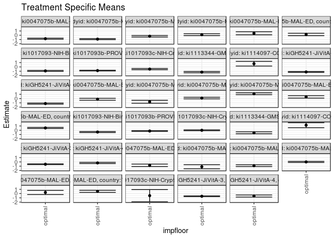

## Results Table

### Parameter: TSM

| agecat | studyid | country | intervention_level | baseline_level | estimate | ci_lower | ci_upper |
| --- | --- | --- | --- | --- | --- | --- | --- |
| Birth | ki0047075b-MAL-ED | BANGLADESH | optimal | observed | -0.7972588 | -1.0872489 | -0.5072686 |
| Birth | ki0047075b-MAL-ED | INDIA | optimal | observed | -1.1382324 | -1.6137633 | -0.6627015 |
| Birth | ki0047075b-MAL-ED | NEPAL | optimal | observed | -0.8889771 | -1.0983970 | -0.6795572 |
| Birth | ki0047075b-MAL-ED | PERU | optimal | observed | -0.0018483 | -0.1282505 | 0.1245540 |
| Birth | ki0047075b-MAL-ED | SOUTH AFRICA | optimal | observed | 0.2595333 | -0.2303635 | 0.7494301 |
| Birth | ki0047075b-MAL-ED | TANZANIA, UNITED REPUBLIC OF | optimal | observed | 0.5258874 | 0.2747347 | 0.7770401 |
| Birth | ki1017093c-NIH-Crypto | BANGLADESH | optimal | observed | -0.4903684 | -1.9162226 | 0.9354858 |
| Birth | kiGH5241-JiVitA-3 | BANGLADESH | optimal | observed | -0.6275105 | -0.7085340 | -0.5464869 |
| Birth | kiGH5241-JiVitA-4 | BANGLADESH | optimal | observed | -0.5750748 | -0.8196785 | -0.3304711 |
| 6 months | ki0047075b-MAL-ED | BANGLADESH | optimal | observed | -0.1561776 | -0.3804757 | 0.0681206 |
| 6 months | ki0047075b-MAL-ED | INDIA | optimal | observed | -0.7479383 | -1.0935176 | -0.4023589 |
| 6 months | ki0047075b-MAL-ED | NEPAL | optimal | observed | 0.1132973 | -0.0732673 | 0.2998619 |
| 6 months | ki0047075b-MAL-ED | PERU | optimal | observed | 1.1268449 | 0.9125712 | 1.3411186 |
| 6 months | ki0047075b-MAL-ED | SOUTH AFRICA | optimal | observed | 0.3990958 | 0.1194250 | 0.6787666 |
| 6 months | ki0047075b-MAL-ED | TANZANIA, UNITED REPUBLIC OF | optimal | observed | 0.5333576 | 0.3996641 | 0.6670511 |
| 6 months | ki1017093-NIH-Birth | BANGLADESH | optimal | observed | -0.4228624 | -0.5499097 | -0.2958151 |
| 6 months | ki1017093b-PROVIDE | BANGLADESH | optimal | observed | -0.1864317 | -0.2742584 | -0.0986050 |
| 6 months | ki1017093c-NIH-Crypto | BANGLADESH | optimal | observed | -0.0069658 | -0.1109889 | 0.0970574 |
| 6 months | ki1113344-GMS-Nepal | NEPAL | optimal | observed | -0.5935528 | -0.8218605 | -0.3652451 |
| 6 months | ki1114097-CONTENT | PERU | optimal | observed | 1.1812306 | 0.5971689 | 1.7652923 |
| 6 months | kiGH5241-JiVitA-3 | BANGLADESH | optimal | observed | -0.5487133 | -0.6318115 | -0.4656151 |
| 6 months | kiGH5241-JiVitA-4 | BANGLADESH | optimal | observed | -0.2393792 | -0.3808640 | -0.0978944 |
| 24 months | ki0047075b-MAL-ED | BANGLADESH | optimal | observed | -0.8117197 | -0.9383350 | -0.6851044 |
| 24 months | ki0047075b-MAL-ED | INDIA | optimal | observed | -0.9088661 | -1.0300861 | -0.7876460 |
| 24 months | ki0047075b-MAL-ED | NEPAL | optimal | observed | -0.2278614 | -0.4070461 | -0.0486766 |
| 24 months | ki0047075b-MAL-ED | PERU | optimal | observed | 0.1326348 | -0.0822524 | 0.3475219 |
| 24 months | ki0047075b-MAL-ED | SOUTH AFRICA | optimal | observed | 0.4562911 | 0.0959044 | 0.8166778 |
| 24 months | ki0047075b-MAL-ED | TANZANIA, UNITED REPUBLIC OF | optimal | observed | 0.1847834 | -0.0990196 | 0.4685864 |
| 24 months | ki1017093-NIH-Birth | BANGLADESH | optimal | observed | -0.9363352 | -1.0573545 | -0.8153158 |
| 24 months | ki1017093b-PROVIDE | BANGLADESH | optimal | observed | -0.8681079 | -0.9542043 | -0.7820114 |
| 24 months | ki1017093c-NIH-Crypto | BANGLADESH | optimal | observed | -0.5125095 | -0.6575558 | -0.3674632 |
| 24 months | ki1113344-GMS-Nepal | NEPAL | optimal | observed | -1.2206562 | -1.3742520 | -1.0670604 |
| 24 months | ki1114097-CONTENT | PERU | optimal | observed | 0.7554201 | 0.2002944 | 1.3105457 |
| 24 months | kiGH5241-JiVitA-3 | BANGLADESH | optimal | observed | -1.1785029 | -1.2835385 | -1.0734674 |
| 24 months | kiGH5241-JiVitA-4 | BANGLADESH | optimal | observed | -1.1632855 | -1.2921547 | -1.0344164 |

### Parameter: E(Y)

| agecat | studyid | country | intervention_level | baseline_level | estimate | ci_lower | ci_upper |
| --- | --- | --- | --- | --- | --- | --- | --- |
| Birth | ki0047075b-MAL-ED | BANGLADESH | observed | observed | -0.9902252 | -1.1311070 | -0.8493435 |
| Birth | ki0047075b-MAL-ED | INDIA | observed | observed | -1.0536702 | -1.1965043 | -0.9108361 |
| Birth | ki0047075b-MAL-ED | NEPAL | observed | observed | -0.9364780 | -1.0810831 | -0.7918728 |
| Birth | ki0047075b-MAL-ED | PERU | observed | observed | -0.0384921 | -0.1542085 | 0.0772244 |
| Birth | ki0047075b-MAL-ED | SOUTH AFRICA | observed | observed | -0.0073148 | -0.1632037 | 0.1485740 |
| Birth | ki0047075b-MAL-ED | TANZANIA, UNITED REPUBLIC OF | observed | observed | 0.8080531 | 0.6030895 | 1.0130167 |
| Birth | ki1017093c-NIH-Crypto | BANGLADESH | observed | observed | -0.7508696 | -1.2358912 | -0.2658480 |
| Birth | kiGH5241-JiVitA-3 | BANGLADESH | observed | observed | -0.7235197 | -0.7433637 | -0.7036757 |
| Birth | kiGH5241-JiVitA-4 | BANGLADESH | observed | observed | -0.3683163 | -0.4490504 | -0.2875821 |
| 6 months | ki0047075b-MAL-ED | BANGLADESH | observed | observed | -0.1354618 | -0.2647919 | -0.0061317 |
| 6 months | ki0047075b-MAL-ED | INDIA | observed | observed | -0.7056667 | -0.8312524 | -0.5800810 |
| 6 months | ki0047075b-MAL-ED | NEPAL | observed | observed | 0.1286317 | -0.0051407 | 0.2624042 |
| 6 months | ki0047075b-MAL-ED | PERU | observed | observed | 1.0527407 | 0.9299728 | 1.1755087 |
| 6 months | ki0047075b-MAL-ED | SOUTH AFRICA | observed | observed | 0.5403280 | 0.3866002 | 0.6940558 |
| 6 months | ki0047075b-MAL-ED | TANZANIA, UNITED REPUBLIC OF | observed | observed | 0.5162517 | 0.3853881 | 0.6471153 |
| 6 months | ki1017093-NIH-Birth | BANGLADESH | observed | observed | -0.4362094 | -0.5254855 | -0.3469333 |
| 6 months | ki1017093b-PROVIDE | BANGLADESH | observed | observed | -0.2083706 | -0.2927992 | -0.1239419 |
| 6 months | ki1017093c-NIH-Crypto | BANGLADESH | observed | observed | 0.0297622 | -0.0491685 | 0.1086930 |
| 6 months | ki1113344-GMS-Nepal | NEPAL | observed | observed | -0.6267309 | -0.7246812 | -0.5287807 |
| 6 months | ki1114097-CONTENT | PERU | observed | observed | 1.0684318 | 0.9515274 | 1.1853362 |
| 6 months | kiGH5241-JiVitA-3 | BANGLADESH | observed | observed | -0.5926720 | -0.6122891 | -0.5730549 |
| 6 months | kiGH5241-JiVitA-4 | BANGLADESH | observed | observed | -0.3901347 | -0.4273932 | -0.3528762 |
| 24 months | ki0047075b-MAL-ED | BANGLADESH | observed | observed | -0.8208255 | -0.9429246 | -0.6987264 |
| 24 months | ki0047075b-MAL-ED | INDIA | observed | observed | -0.9522907 | -1.0676596 | -0.8369219 |
| 24 months | ki0047075b-MAL-ED | NEPAL | observed | observed | -0.3487330 | -0.4631704 | -0.2342957 |
| 24 months | ki0047075b-MAL-ED | PERU | observed | observed | 0.1199005 | -0.0000331 | 0.2398341 |
| 24 months | ki0047075b-MAL-ED | SOUTH AFRICA | observed | observed | 0.4267017 | 0.3074751 | 0.5459283 |
| 24 months | ki0047075b-MAL-ED | TANZANIA, UNITED REPUBLIC OF | observed | observed | 0.0429953 | -0.0825155 | 0.1685060 |
| 24 months | ki1017093-NIH-Birth | BANGLADESH | observed | observed | -0.9106710 | -1.0090143 | -0.8123277 |
| 24 months | ki1017093b-PROVIDE | BANGLADESH | observed | observed | -0.8879412 | -0.9708680 | -0.8050144 |
| 24 months | ki1017093c-NIH-Crypto | BANGLADESH | observed | observed | -0.6103502 | -0.7050157 | -0.5156847 |
| 24 months | ki1113344-GMS-Nepal | NEPAL | observed | observed | -1.1914974 | -1.2943015 | -1.0886933 |
| 24 months | ki1114097-CONTENT | PERU | observed | observed | 0.5668293 | 0.4302437 | 0.7034148 |
| 24 months | kiGH5241-JiVitA-3 | BANGLADESH | observed | observed | -1.2970420 | -1.3203145 | -1.2737694 |
| 24 months | kiGH5241-JiVitA-4 | BANGLADESH | observed | observed | -1.2232311 | -1.2550891 | -1.1913732 |

### Parameter: PAR

| agecat | studyid | country | intervention_level | baseline_level | estimate | ci_lower | ci_upper |
| --- | --- | --- | --- | --- | --- | --- | --- |
| Birth | ki0047075b-MAL-ED | BANGLADESH | optimal | observed | -0.1929664 | -0.4993819 | 0.1134490 |
| Birth | ki0047075b-MAL-ED | INDIA | optimal | observed | 0.0845622 | -0.3586379 | 0.5277623 |
| Birth | ki0047075b-MAL-ED | NEPAL | optimal | observed | -0.0475009 | -0.1856235 | 0.0906217 |
| Birth | ki0047075b-MAL-ED | PERU | optimal | observed | -0.0366438 | -0.1066479 | 0.0333603 |
| Birth | ki0047075b-MAL-ED | SOUTH AFRICA | optimal | observed | -0.2668481 | -0.7417570 | 0.2080608 |
| Birth | ki0047075b-MAL-ED | TANZANIA, UNITED REPUBLIC OF | optimal | observed | 0.2821657 | 0.1083377 | 0.4559937 |
| Birth | ki1017093c-NIH-Crypto | BANGLADESH | optimal | observed | -0.2605012 | -1.4929517 | 0.9719494 |
| Birth | kiGH5241-JiVitA-3 | BANGLADESH | optimal | observed | -0.0960093 | -0.1743618 | -0.0176567 |
| Birth | kiGH5241-JiVitA-4 | BANGLADESH | optimal | observed | 0.2067585 | -0.0230858 | 0.4366029 |
| 6 months | ki0047075b-MAL-ED | BANGLADESH | optimal | observed | 0.0207158 | -0.1585346 | 0.1999661 |
| 6 months | ki0047075b-MAL-ED | INDIA | optimal | observed | 0.0422716 | -0.3004687 | 0.3850118 |
| 6 months | ki0047075b-MAL-ED | NEPAL | optimal | observed | 0.0153344 | -0.1198953 | 0.1505641 |
| 6 months | ki0047075b-MAL-ED | PERU | optimal | observed | -0.0741041 | -0.2497522 | 0.1015439 |
| 6 months | ki0047075b-MAL-ED | SOUTH AFRICA | optimal | observed | 0.1412322 | -0.1208061 | 0.4032704 |
| 6 months | ki0047075b-MAL-ED | TANZANIA, UNITED REPUBLIC OF | optimal | observed | -0.0171059 | -0.0539068 | 0.0196950 |
| 6 months | ki1017093-NIH-Birth | BANGLADESH | optimal | observed | -0.0133470 | -0.1036478 | 0.0769538 |
| 6 months | ki1017093b-PROVIDE | BANGLADESH | optimal | observed | -0.0219388 | -0.0456818 | 0.0018041 |
| 6 months | ki1017093c-NIH-Crypto | BANGLADESH | optimal | observed | 0.0367280 | -0.0258137 | 0.0992698 |
| 6 months | ki1113344-GMS-Nepal | NEPAL | optimal | observed | -0.0331781 | -0.2391159 | 0.1727597 |
| 6 months | ki1114097-CONTENT | PERU | optimal | observed | -0.1127988 | -0.6737385 | 0.4481408 |
| 6 months | kiGH5241-JiVitA-3 | BANGLADESH | optimal | observed | -0.0439587 | -0.1260522 | 0.0381348 |
| 6 months | kiGH5241-JiVitA-4 | BANGLADESH | optimal | observed | -0.1507555 | -0.2883335 | -0.0131774 |
| 24 months | ki0047075b-MAL-ED | BANGLADESH | optimal | observed | -0.0091058 | -0.0472869 | 0.0290754 |
| 24 months | ki0047075b-MAL-ED | INDIA | optimal | observed | -0.0434247 | -0.0997729 | 0.0129236 |
| 24 months | ki0047075b-MAL-ED | NEPAL | optimal | observed | -0.1208717 | -0.2585009 | 0.0167575 |
| 24 months | ki0047075b-MAL-ED | PERU | optimal | observed | -0.0127343 | -0.1926777 | 0.1672092 |
| 24 months | ki0047075b-MAL-ED | SOUTH AFRICA | optimal | observed | -0.0295894 | -0.3786352 | 0.3194563 |
| 24 months | ki0047075b-MAL-ED | TANZANIA, UNITED REPUBLIC OF | optimal | observed | -0.1417881 | -0.4080088 | 0.1244326 |
| 24 months | ki1017093-NIH-Birth | BANGLADESH | optimal | observed | 0.0256642 | -0.0685599 | 0.1198882 |
| 24 months | ki1017093b-PROVIDE | BANGLADESH | optimal | observed | -0.0198333 | -0.0454868 | 0.0058202 |
| 24 months | ki1017093c-NIH-Crypto | BANGLADESH | optimal | observed | -0.0978407 | -0.2148536 | 0.0191722 |
| 24 months | ki1113344-GMS-Nepal | NEPAL | optimal | observed | 0.0291588 | -0.1053768 | 0.1636944 |
| 24 months | ki1114097-CONTENT | PERU | optimal | observed | -0.1885908 | -0.7332959 | 0.3561143 |
| 24 months | kiGH5241-JiVitA-3 | BANGLADESH | optimal | observed | -0.1185390 | -0.2201266 | -0.0169515 |
| 24 months | kiGH5241-JiVitA-4 | BANGLADESH | optimal | observed | -0.0599456 | -0.1841640 | 0.0642728 |